# W3cubDocs

/Statsmodels

# Statsmodels Examples

This page provides a series of examples, tutorials and recipes to help you get started with statsmodels. Each of the examples shown here is made available as an IPython Notebook and as a plain python script on the [statsmodels github repository](https://github.com/statsmodels/statsmodels/tree/master/examples).  
If you are not comfortable with git, we also encourage users to submit their own examples, tutorials or cool statsmodels tricks to the [Examples wiki page](https://github.com/statsmodels/statsmodels/wiki/Examples).

## Topics

- Linear Regression Models
- Plotting
- Discrete Choice Models
- Nonparametric Statistics
- Generalized Linear Models
- Robust Regression
- Statistics
- Time Series Analysis
- State space models
- User Notes

## Linear Regression Models

- Ordinary Least Squares

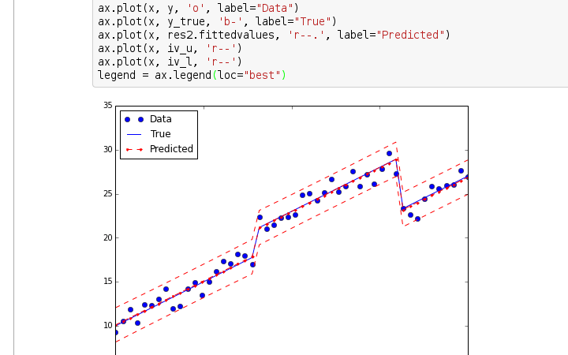

- Generalized Least Squares

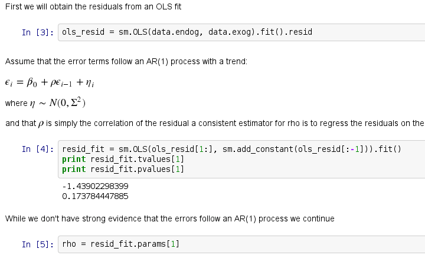

- Quantile Regression

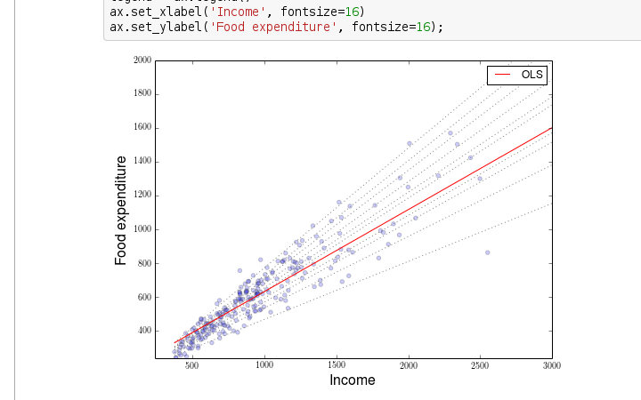

- Recursive Least Squares

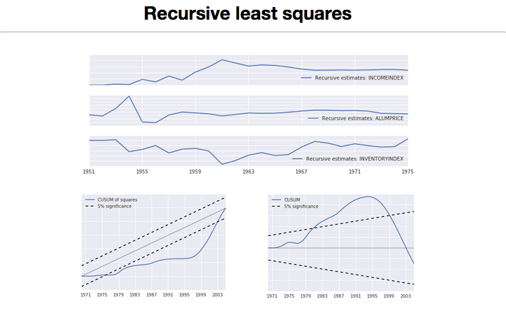

- Regression Diagnostics

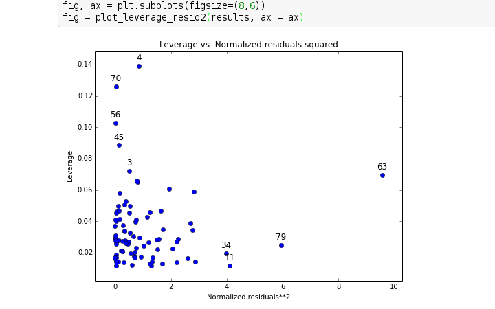

- Weighted Least Squares

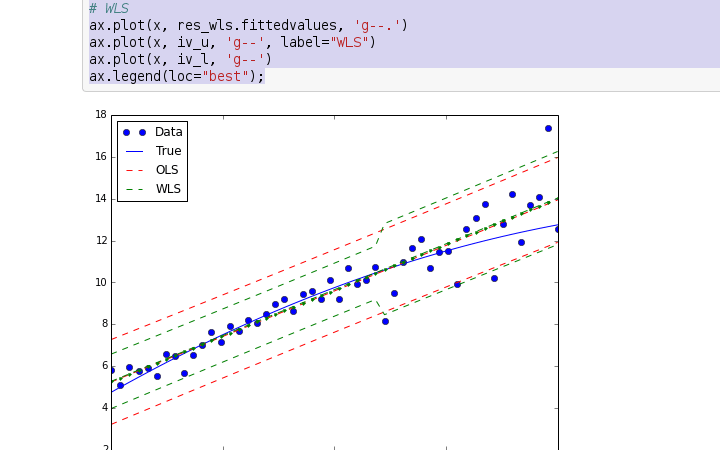

- Linear Mixed-Effects

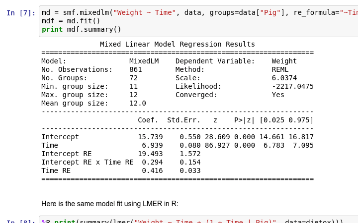

## Plotting

- Regression Plots

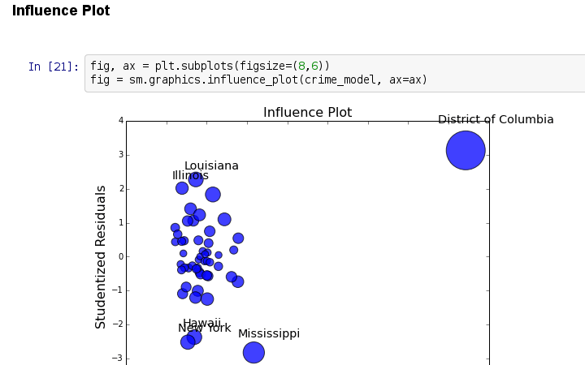

- Categorical Interactions

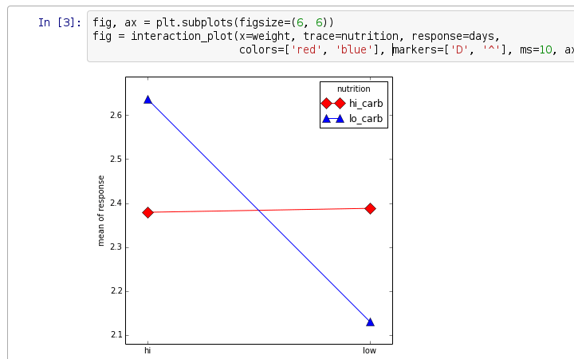

## Discrete Choice Models

- Getting Started

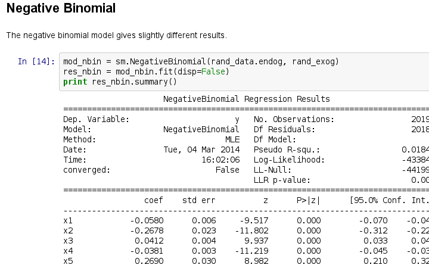

- Fair's Affairs Data

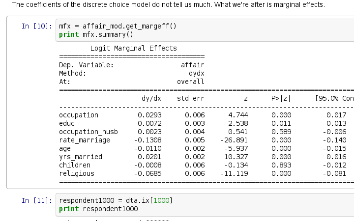

## Nonparametric Statistics

- Univariate Kernel Density Estimator

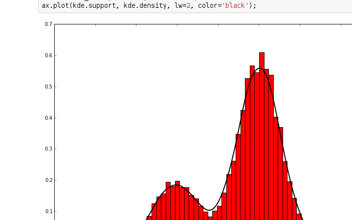

## Generalized Linear Models

- Generalized Linear Models Overview

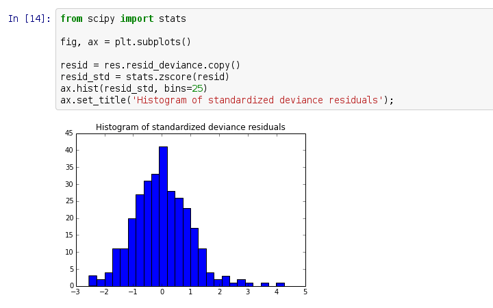

- Using Formulas with GLMs

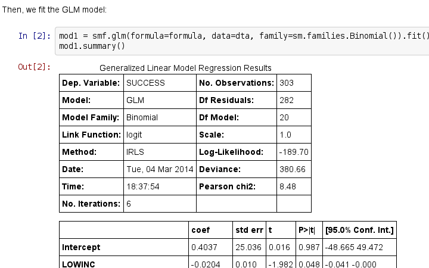

## Robust Regression

- M-estimators for Robust Regression

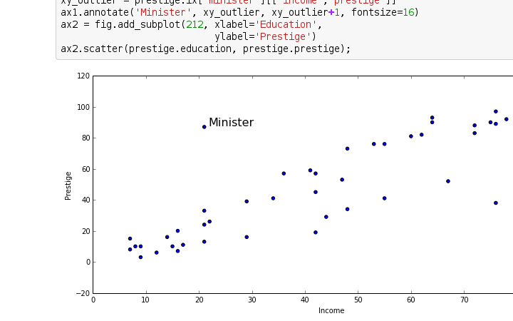

- Comparing OLS and RLM

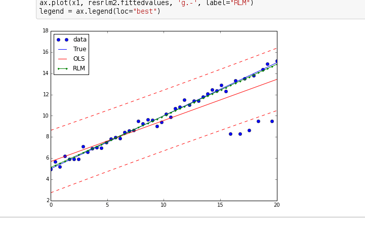

## Statistics

- ANOVA

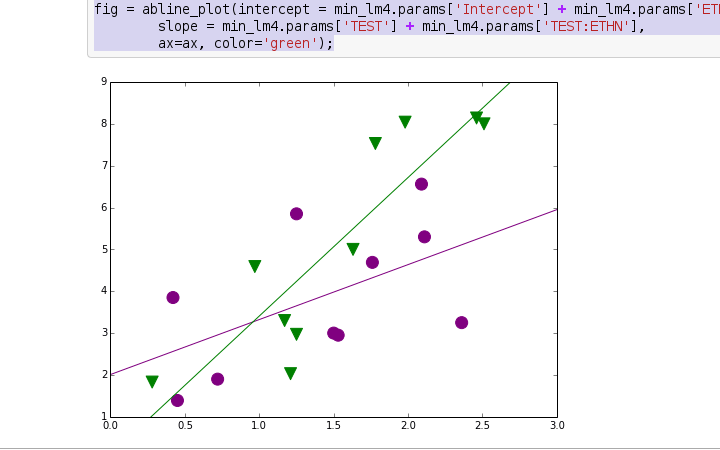

## Time Series Analysis

- ARMA: Sunspots Data

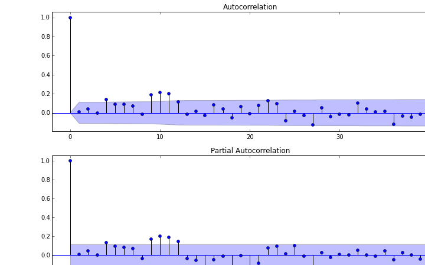

- ARMA: Artificial Data

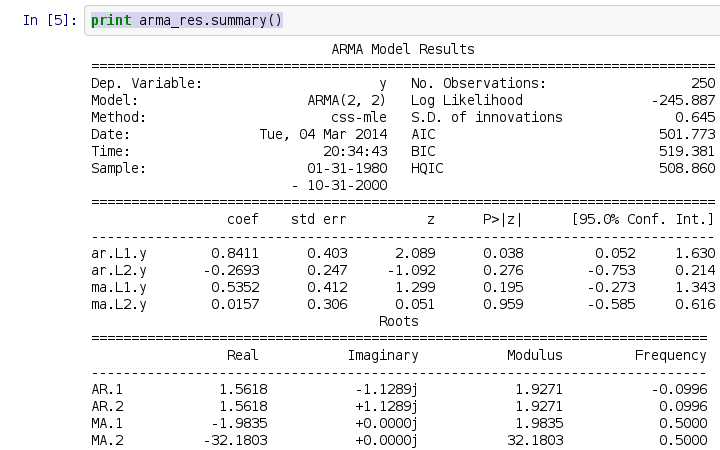

- Time Series Filters

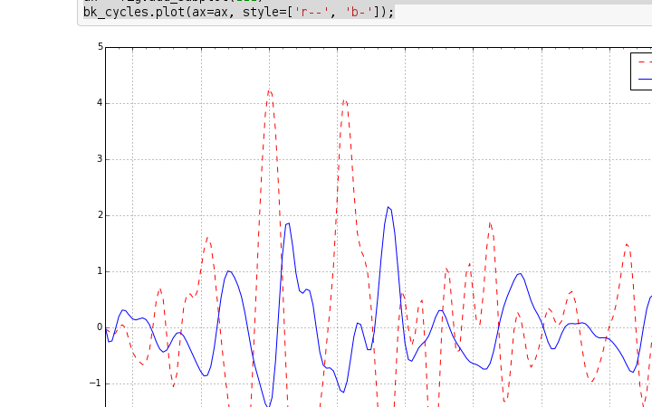

- Markov switching dynamic regression

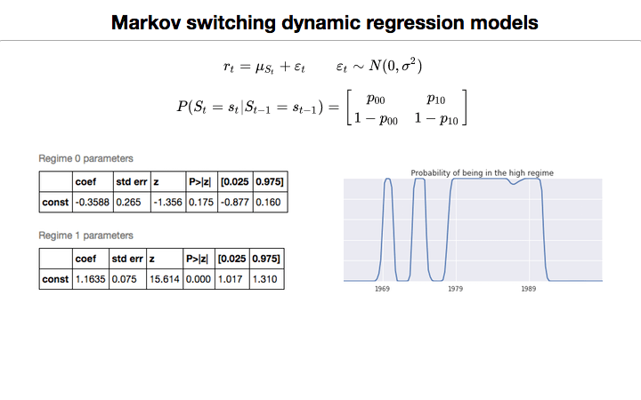

- Markov switching autoregression

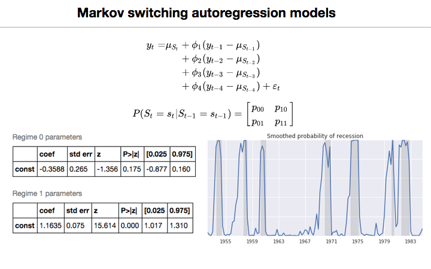

## State space models

- SARIMAX: Introduction

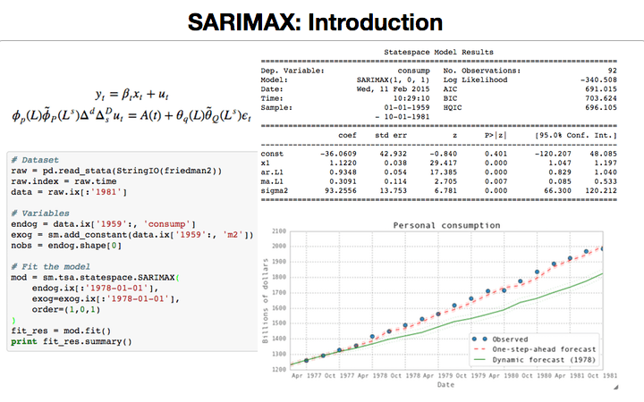

- SARIMAX: Model selection, missing data

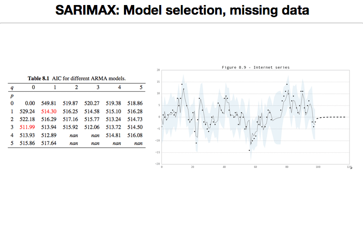

- VARMAX: introduction

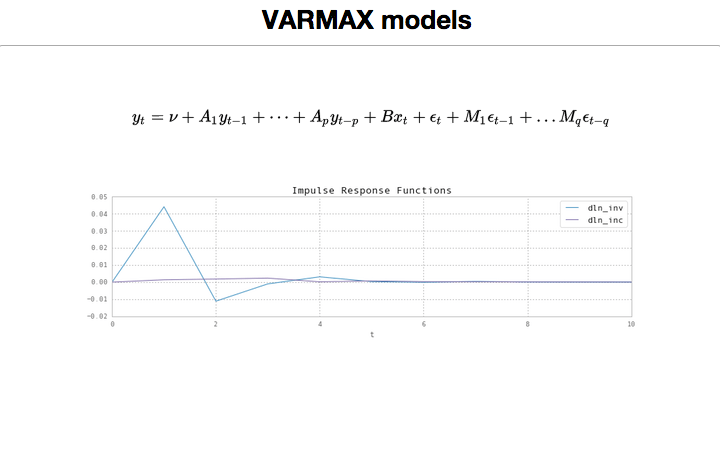

- Dynamic Factor Models: Application

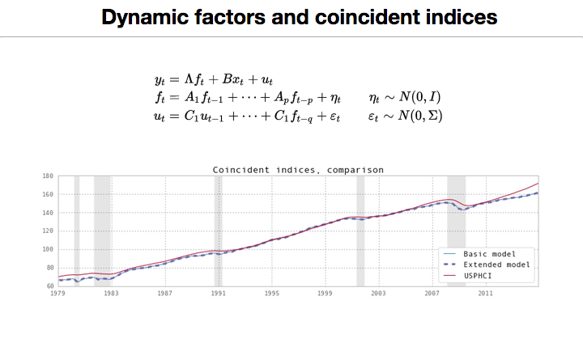

- Unobserved Components: Application

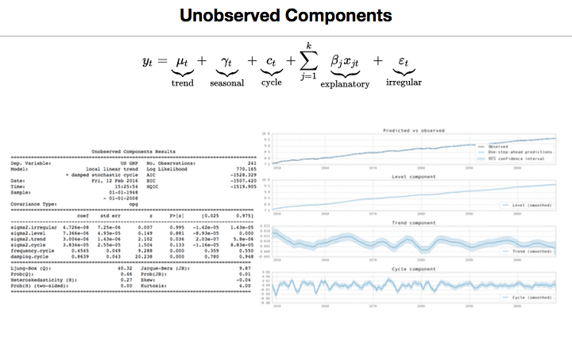

- Trends and cycles in unemployment

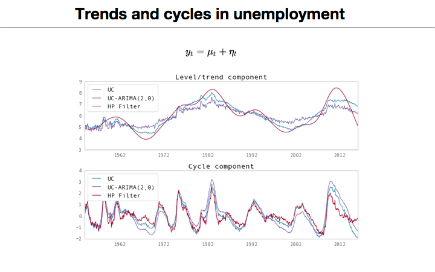

- State space modeling: Local Linear Trends

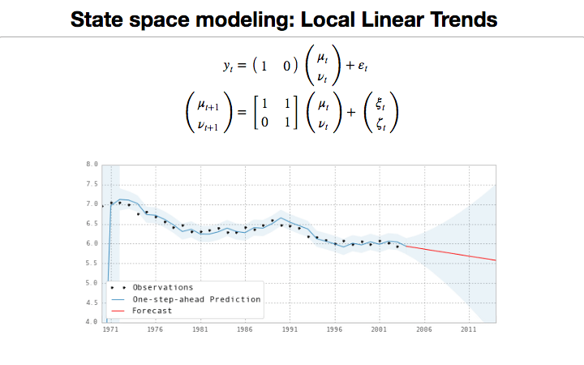

[figure not shown]